# Correlation of Country Goverment Index & GDP Captia

- Show All Code
- Hide All Code
- View Source

Author

Brian Kwong, Connor Gamba, Joey Bailitz, Arneh Begi

## Names:

- Brian Kwong
- Connor Gamba
- Joey Bailitz
- Arneh Begi

## Import the Needed Libraries

Please make sure you have the following libraries installed:

1. Tidyverse
2. Here
3. Janitor
4. Styler
5. Reactablefmtr

```r
# Set output scope
options(scipen = 0)

# Clears environment
remove(list = as.vector(ls()))

#| output: False
library(tidyverse)
library(janitor)
library(styler)
library(reactablefmtr)
library(gganimate)
library(gapminder)
library(gifski)

# Formats documents:
style_file(path = here::here("Src", "Correlation_of_Country_Goverment_Index_&_GDP_Captia.qmd"), style = tidyverse_style, strict = TRUE)
```

# Introduction

## Background

The following data contains data collected on countries GDP and independent international calculation of a absence of corruption index from a variety of factors including government transparency, public official use of state dollars for personal gain and general trust in government officials being truthful in their actions between the years 1975 and 2021. Higher absence corruption index signals *lower* perceived corruption.

# Our Data

## Importing the Data

```r
curruption_data <- read_csv(here::here("Datasets", "abscorrup_idea.csv"), show_col_types = FALSE) |> janitor::clean_names()

gdp_per_cap_data <- read_csv(here::here("Datasets", "gdp_pcap.csv"), show_col_types = FALSE) |> janitor::clean_names()
```

## Matching Our Daaset

Since our corruption only has data for years between [1975,2021] we filter our GDP per captia to those years too

```r
gdp_per_cap_data <- gdp_per_cap_data |> select(country, c(x1975:x2021))
```

## Piviot Data to Long Format

```r
curruption_data <- curruption_data |>
  pivot_longer(cols = c(x1975:x2021), names_to = "Year", values_to = "Absence_Corruption_Index") |>
  mutate(Absence_Corruption_Index = as.numeric(Absence_Corruption_Index))

gdp_per_cap_data <- gdp_per_cap_data |>
  pivot_longer(cols = c(x1975:x2021), names_to = "Year", values_to = "GDP_Per_Capita") |>
  mutate(GDP_Per_Capita = if_else(str_detect(GDP_Per_Capita, "k$"), (as.numeric(str_remove_all(GDP_Per_Capita, "k$")) * 10000), as.numeric(GDP_Per_Capita)))
```

## Data Joins

```r
full_data <- curruption_data |> inner_join(gdp_per_cap_data, by = c("country", "Year"))

full_data <- full_data |>
  mutate(country = as_factor(country)) |>
  mutate(region = as.factor(case_when(
    country %in% c(
      "Antigua and Barbuda", "Argentina", "Bahamas", "Barbados",
      "Belize", "Bolivia", "Brazil", "Canada", "Chile", "Colombia",
      "Costa Rica", "Cuba", "Dominica", "Dominican Republic",
      "Ecuador", "El Salvador", "Grenada", "Guatemala", "Guyana",
      "Haiti", "Honduras", "Jamaica", "Mexico", "Nicaragua", "Panama",
      "Paraguay", "Peru", "St. Kitts and Nevis", "St. Lucia",
      "St. Vincent and the Grenadines", "Suriname",
      "Trinidad and Tobago", "USA", "Uruguay",
      "Venezuela"
    ) ~ "The Americas",
    country %in% c(
      "Albania", "Andorra", "Armenia", "Austria", "Azerbaijan",
      "Belarus", "Belgium", "Bosnia and Herzegovina", "Bulgaria",
      "Croatia", "Cyprus", "Czech Republic", "Denmark", "Estonia",
      "Finland", "France", "Georgia", "Germany", "Greece", "Holy See",
      "Hungary", "Iceland", "Ireland", "Italy", "Latvia",
      "Liechtenstein", "Lithuania", "Luxembourg", "North Macedonia",
      "Malta", "Moldova", "Monaco", "Montenegro", "Netherlands",
      "Norway", "Poland", "Portugal", "Romania", "Russia", "San Marino",
      "Serbia", "Slovak Republic", "Slovenia", "Spain", "Sweden",
      "Switzerland", "Turkey", "Ukraine",
      "UK"
    ) ~ "Europe",
    country %in% c(
      "Algeria", "Angola", "Benin", "Botswana", "Burkina Faso",
      "Burundi", "Cameroon", "Cape Verde", "Central African Republic",
      "Chad", "Comoros", "Congo, Dem. Rep.", "Congo, Rep.",
      "Cote d'Ivoire", "Djibouti", "Egypt", "Equatorial Guinea",
      "Eritrea", "Ethiopia", "Gabon", "Gambia", "Ghana", "Guinea",
      "Guinea-Bissau", "Kenya", "Lesotho", "Liberia", "Libya",
      "Madagascar", "Malawi", "Mali", "Mauritania", "Mauritius",
      "Morocco", "Mozambique", "Namibia", "Niger", "Nigeria", "Rwanda",
      "Sao Tome and Principe", "Senegal", "Seychelles",
      "Sierra Leone", "Somalia", "South Africa", "Sudan", "Eswatini",
      "Tanzania", "Togo", "Tunisia", "Uganda", "Zambia", "Zimbabwe",
      "South Sudan"
    ) ~ "Africa",
    country %in% c(
      "Afghanistan", "Australia", "Bahrain", "Bangladesh", "Bhutan",
      "Brunei", "Cambodia", "China", "Fiji", "Hong Kong, China",
      "India", "Indonesia", "Iran", "Iraq", "Israel", "Japan", "Jordan",
      "Kazakhstan", "Kiribati", "North Korea", "South Korea", "Kuwait",
      "Kyrgyz Republic", "Lao", "Lebanon", "Malaysia", "Maldives",
      "Marshall Islands", "Micronesia, Fed. Sts.", "Mongolia",
      "Myanmar", "Nauru", "Nepal", "New Zealand", "Oman", "Pakistan",
      "Palau", "Papua New Guinea", "Philippines", "Qatar", "Samoa",
      "Saudi Arabia", "Singapore", "Solomon Islands", "Sri Lanka",
      "Syria", "Taiwan", "Tajikistan", "Thailand", "Timor-Leste",
      "Tonga", "Turkmenistan", "Tuvalu", "UAE",
      "Uzbekistan", "Vanuatu", "Palestine", "Vietnam",
      "Yemen"
    ) ~ "Asia-Pacific"
  )))
```

## Understanding Our Data

The following ER diagram represents how our data is structured

[figure not shown]

```r
# ER Diagram
knitr::include_graphics(here::here("Figures", "ERDiagram.png"))
```

[output not shown]

## Summary

```r
full_data |>
  select(country) |>
  summarise(Count = n_distinct(country))
```

[output not shown]

There are a total of *172* countries in this study

Below is a quick summary of the average mean absense corruption Index and GDP per Captia out of every country for every year

```r
full_data |>
  group_by(country) |>
  mutate(across(.cols = c(Absence_Corruption_Index, GDP_Per_Capita), .fns = ~ mean(.x, na.rm = TRUE))) |>
  group_by(Year) |>
  summary() |>
  unclass() |>
  as_tibble() |>
  select(Absence_Corruption_Index, GDP_Per_Capita) |>
  rename("Absence Corruption Index" = Absence_Corruption_Index, " GDP Per Capita" = GDP_Per_Capita)
```

| Absence Corruption Index | GDP Per Capita |
| --- | --- |
| Min. :11.59 | Min. : 781.9 |
| 1st Qu.:32.40 | 1st Qu.: 3385.7 |
| Median :42.69 | Median : 40924.4 |
| Mean :46.41 | Mean :129519.2 |
| 3rd Qu.:57.52 | 3rd Qu.:198925.5 |
| Max. :98.14 | Max. :820276.6 |
| NA | NA |

## About those Pesky NAs

One thing we do want to acknowledge is the presence of NAs in our datasheet particularly in the corruption index. There could be a multitude of reasons why this that data isn’t present for a country in a particular year: data was lost, data was measured/calculated incorrectly, some disaster prevent the data from being collected, insufficient stability for determination to occur or the government doesn’t want the public to know about their corruption therefore attempts to censor it. All these factors some, randomized some not will be taken into our consideration when determining the relationship between corruption index and GDP per captia

## Possible Hypothesis

- Explanatory Variable : Absence of Curruption of Index
- Response Variable : GDP Per Captia

We believe that a higher absence of corruption index will lead to a higher GDP per captia. Traditionally are more stable and democratic forms of governments have higher standards of living,less internal/external conflicts, equal opportunities for all individuals and large amounts of well fares for their constituency. They also in general have stronger economies that are more reliant to wild economic swings For instance much of modern Europe has a high GDP per captia because of its modernization, democratic governments and tight integration with the EU.

# Data Visualizations

```r
# Renames the year from xYYYY -> YYYY
full_data <- full_data |> mutate(Year = as.numeric(str_remove_all(Year, "^x")))
```

Below is a plot of countries and their respective Absence of Corruption Index vrs. GDP Per Captia in the year 2021

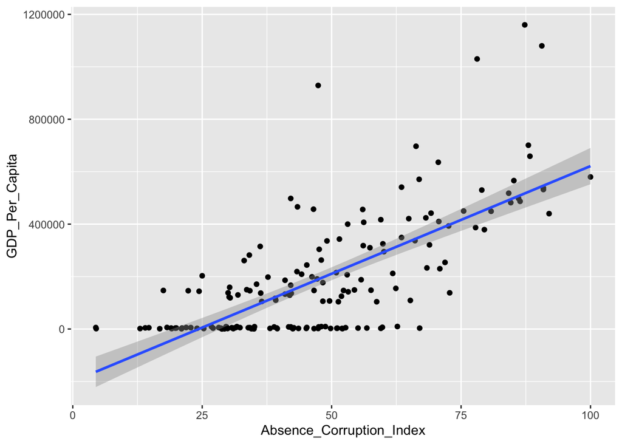

```r
full_data |>
  filter(Year == 2021) |>
  ggplot(mapping = aes(x = Absence_Corruption_Index, y = GDP_Per_Capita)) +
  geom_point() +
  geom_smooth(method = "lm")
```

As many of our countries have quite poor GDP-per-Captia they are all bunched up on the bottom making it quite hard to visualize. We will therefore log transform our Y-axis to get a better view of this relationship

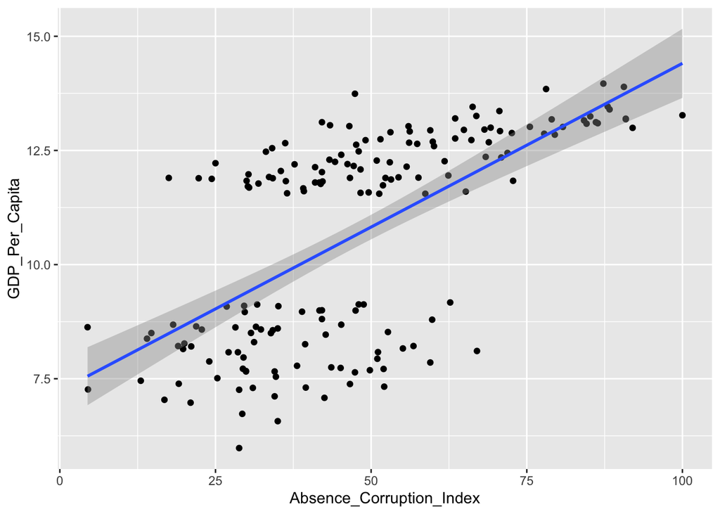

```r
# With Log Transformation
full_data |>
  filter(Year == 2021) |>
  mutate(GDP_Per_Capita = log(GDP_Per_Capita)) |>
  ggplot(mapping = aes(x = Absence_Corruption_Index, y = GDP_Per_Capita)) +
  geom_point() +
  geom_smooth(method = "lm")
```

# Data Modeling & Prediction

## Creating our Regression Models

While the log transformation gives us a easier way to see the upwards trend between Absence of Corruption Index and the nation’s GDP per Captia, it actually does *NOT* help our linear model, in fact comparing the computed R-squared values is *worse* on the log transformed model.

```r
# 2021 Data

full_2021_data <- full_data |> filter(Year == 2021)

# 2021 Data with log transformation

log_2021_data <- full_2021_data |> mutate(GDP_Per_Capita = log(GDP_Per_Capita))
```

```r
full_2021_data_lm <- lm(GDP_Per_Capita ~ Absence_Corruption_Index, full_2021_data)
log_2021_data_lm <- lm(GDP_Per_Capita ~ Absence_Corruption_Index, log_2021_data)
tibble("R Squared Non Transformed" = summary(full_2021_data_lm)$r.squared, "R Squared Log Transformed" = summary(log_2021_data_lm)$r.squared) |>
  reactable() |>
  add_title("Comparison of R Squared of Two Linear Models", font_size = 20, align = "center")
```

Comparison of R Squared of Two Linear Models

| R Squared Non Transformed | R Squared Log Transformed |
| --- | --- |
| 0.505103598209365 | 0.394936877722502 |

With that in mind, we will be sticking with our untransformed data for the remainder of this exploration.

```r
# Removes the transformed log models
remove(log_2021_data, log_2021_data_lm)

# Summary of Linear Model :
broom::tidy(full_2021_data_lm) |>
  rename("Regression Variable" = term, "Model Estimate" = estimate, "Standard Error" = std.error) |>
  select(c("Regression Variable":"Standard Error"))
```

| Regression Variable | Model Estimate | Standard Error |
| --- | --- | --- |
| (Intercept) | -199747.304 | 31994.4920 |
| Absence_Corruption_Index | 8211.695 | 623.4122 |

Our linear model comparing different countries in 2021 and their respective Absence of Corruption Index vrs their 2021 GDP Per Captia yeilds us the following results

$$\beta_0 = -199747.304\\
\beta_1 = 8211.695$$
which will give us the linear regression formula of :
$$\hat{y} = -199747.304+8211.695x$$

or rewritten with our explanatory and response variables
$$\hat{GDP\_Per\_Captia} = -199747.304+8211.695(Absence\_Corruption\_Index)$$

## Checking the Linear Model’s Accuracy

Although we have a mild $R^2$ relation between Absence of Corruption Index and its response variable GDP per Captia, we want to still check the model fit. One way to check the average residual of our model

```r
full_2021_data_lm_resd <- full_2021_data_lm |>
  broom::augment() |>
  select(.resid)
full_2021_data_lm_resd |>
  summarize("Avergae Residual" = mean(.resid)) |>
  reactable() |>
  add_title("Model Residual Stats", font_size = 20, align = "center")
```

Model Residual Stats

| Avergae Residual |
| --- |
| -1.76695784618861e-10 |

With a average residual $<|10^{-9}|$ this looks pretty promising, but to confirm our calculations and better visualize the distributions of residuals lets plot them on a histogram. What we expect is a normal distribution of all residuals reminiscent of the familiar bell curve.

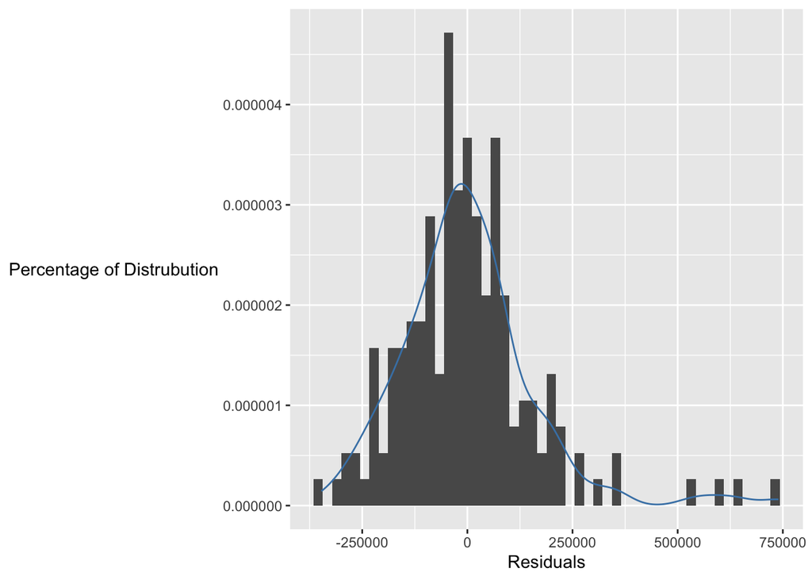

```r
options(scipen = 100)
full_2021_data_lm_resd |> ggplot(mapping = aes(x = .resid)) +
  geom_histogram(aes(y = ..density..), bins = 50) +
  labs(x = "Residuals", y = "Percentage of Distrubution") +
  geom_density(colour = "steelblue") +
  theme(axis.title.y = element_text(angle = 0, vjust = 0.5))
```

```r
library(gapminder)
library(gganimate)
library(gifski)
library(av)

ggplot(full_data, aes(x = Absence_Corruption_Index, y = GDP_Per_Capita, color = country)) +
  geom_point(alpha = 0.7, show.legend = FALSE) +
  scale_size(range = c(2, 12)) +
  scale_x_log10() +
  # facet_wrap(~continent) +
  # Here comes the gganimate specific bits
  labs(title = "Year: {frame_time}", x = "GDP per capita", y = "life expectancy") +
  transition_time(year) +
  ease_aes("linear")
```

[output not shown]